# Biostat 212a Homework 1

Due Jan 25, 2026 @ 11:59PM

Author

Published

January 25, 2026

## 1 Filling gaps in lecture notes (10% pts)

Consider the regression model
$$Y = f(X) + \epsilon,$$
where $\operatorname{E}(\epsilon) = 0$.

### 1.1 Optimal regression function

Show that the choice
$$f_{\text{opt}}(X) = \operatorname{E}(Y | X)$$
minimizes the mean squared prediction error
$$\operatorname{E}\{[Y - f(X)]^2\},$$
where the expectations averages over variations in both $X$ and $Y$. (Hint: condition on $X$.)

#### 1.1.1 Proof

Using the law of total expectation,

$$\mathbb{E}\{[Y - f(X)]^2\}
= \mathbb{E}\bigl[ \mathbb{E}\{[Y - f(X)]^2 \mid X\} \bigr].$$

For a fixed value of $X$,

$$\mathbb{E}\{[Y - f(X)]^2 \mid X\}
= \mathbb{E}\{[Y - \mathbb{E}(Y\mid X) + \mathbb{E}(Y\mid X) - f(X)]^2 \mid X\}.$$

Expanding the square,

$$\begin{aligned}
= {} & \mathbb{E}\{[Y - \mathbb{E}(Y\mid X)]^2 \mid X\} \\
& + [\mathbb{E}(Y\mid X) - f(X)]^2 \\
& + 2\,\mathbb{E}\{[Y - \mathbb{E}(Y\mid X)] \mid X\}[\mathbb{E}(Y\mid X) - f(X)].
\end{aligned}$$

The cross term is zero because

$$\mathbb{E}\{Y - \mathbb{E}(Y\mid X)\mid X\} = 0.$$

Therefore,

$$\mathbb{E}\{[Y - f(X)]^2 \mid X\}
= \operatorname{Var}(Y\mid X)
+ [\mathbb{E}(Y\mid X) - f(X)]^2.$$

Taking expectation over $X$,

$$\mathbb{E}\{[Y - f(X)]^2\}
= \mathbb{E}[\operatorname{Var}(Y\mid X)]
+ \mathbb{E}\{[\mathbb{E}(Y\mid X) - f(X)]^2\}.$$

The first term does not depend on $f$, so the expression is minimized when

$$f(X) = \mathbb{E}(Y\mid X).$$

Hence,

$$f_{\text{opt}}(X) = \mathbb{E}(Y\mid X)$$

minimizes the mean squared prediction error.

### 1.2 Bias-variance trade-off

Given an estimate $\hat f$ of $f$, show that the test error at a $x_0$ can be decomposed as
$$\operatorname{E}\{[y_0 - \hat f(x_0)]^2\} = \underbrace{\operatorname{Var}(\hat f(x_0)) + [\operatorname{Bias}(\hat f(x_0))]^2}_{\text{MSE of } \hat f(x_0) \text{ for estimating } f(x_0)} + \underbrace{\operatorname{Var}(\epsilon)}_{\text{irreducible}},$$
where the expectation averages over the variability in $y_0$ and $\hat f$.

#### 1.2.1 Proof

Start from

$$y_0 - \hat f(x_0)
= f(x_0) - \hat f(x_0) + \varepsilon.$$

Squaring and taking expectation,

$$\begin{aligned}
\mathbb{E}\{[y_0 - \hat f(x_0)]^2\}
= {} & \mathbb{E}\{[f(x_0) - \hat f(x_0)]^2\} \\
& + \mathbb{E}(\varepsilon^2)
+ 2\,\mathbb{E}\{[f(x_0) - \hat f(x_0)]\varepsilon\}.
\end{aligned}$$

Since $\varepsilon$ has mean zero and is independent of $\hat f$,

$$\mathbb{E}\{[f(x_0) - \hat f(x_0)]\varepsilon\} = 0.$$

Thus,

$$\mathbb{E}\{[y_0 - \hat f(x_0)]^2\}
= \mathbb{E}\{[f(x_0) - \hat f(x_0)]^2\}
+ \operatorname{Var}(\varepsilon).$$

Now decompose the first term:

$$\mathbb{E}\{[f(x_0) - \hat f(x_0)]^2\}
= \operatorname{Var}(\hat f(x_0))
+ [\mathbb{E}(\hat f(x_0)) - f(x_0)]^2.$$

Therefore,

$$\mathbb{E}\{[y_0 - \hat f(x_0)]^2\}
= \operatorname{Var}(\hat f(x_0))
+ [\operatorname{Bias}(\hat f(x_0))]^2
+ \operatorname{Var}(\varepsilon).$$

## 2 ISL Exercise 2.4.3 (10% pts)

### 2.1 Solution to 2.4.3(a)

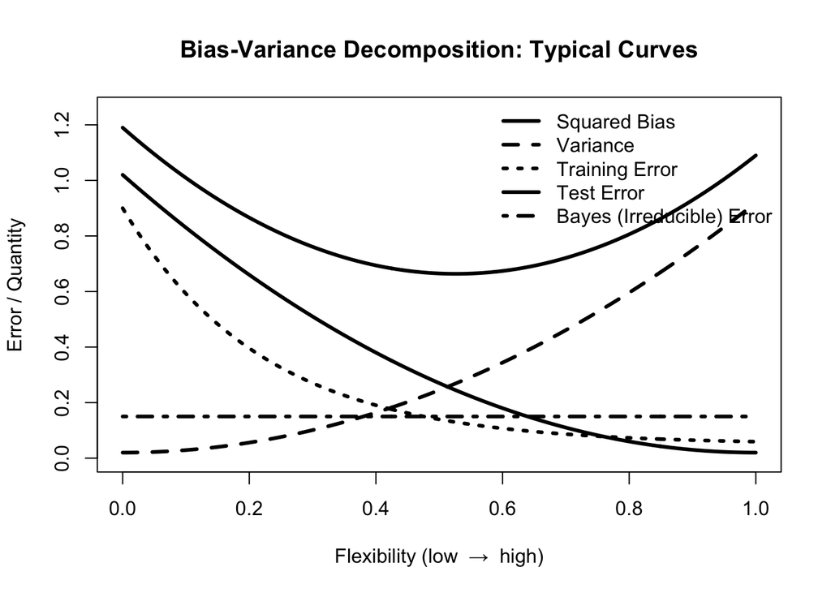

```r
# 1) x-axis: flexibility grid
flex <- seq(0, 1, length.out = 300)

# 2) Construct typical curve shapes
bias2 <- (1 - flex)^2 + 0.02                  # decreasing
var   <- 0.02 + 0.9 * flex^2                  # increasing
bayes <- rep(0.15, length(flex))              # flat (irreducible error)

train_err <- 0.85 * exp(-4.5 * flex) + 0.05   # decreasing, can approach ~0
test_err <- bias2 + var + bayes

# 3) Plot everything on one figure
ylim_max <- max(bias2, var, train_err, test_err, bayes) * 1.05

plot(
  flex, bias2, type = "l", lwd = 3,
  xlab = "Flexibility (low  \u2192  high)",
  ylab = "Error / Quantity",
  ylim = c(0, ylim_max),
  main = "Bias-Variance Decomposition: Typical Curves"
)

lines(flex, var,       lwd = 3, lty = 2)
lines(flex, train_err, lwd = 3, lty = 3)
lines(flex, test_err,  lwd = 3, lty = 1)
lines(flex, bayes,     lwd = 3, lty = 4)

legend(
  "topright", bty = "n", lwd = 3,
  legend = c("Squared Bias", "Variance", "Training Error", "Test Error", "Bayes (Irreducible) Error"),
  lty = c(1, 2, 3, 1, 4)
)
```

### 2.2 Solution to 2.4.3(b)

#### 2.2.1 Squared bias (decreases with flexibility)

Bias measures **systematic error** from using an overly restrictive model class.  
When flexibility is **low**, the model cannot represent the true signal (f(X)) well (underfitting), so the bias is **large**.  
As flexibility increases, the model class can approximate (f(X)) more accurately, so **squared bias decreases**.

#### 2.2.2 Variance (increases with flexibility)

Variance measures how much the fitted function would change if we trained the model on a different sample from the same population.

When model flexibility is **low**, the fitted model is highly constrained and tends to be stable across different training samples, resulting in **low variance**.

As model flexibility increases, the method becomes more sensitive to the particular training data, including random noise. Consequently, predictions can vary substantially across different samples, leading to **higher variance**.

#### 2.2.3 Training error (monotonically decreases)

Training error is computed on the **same data used to fit the model**.  
More flexibility gives the method more freedom to fit the training points, so training error **cannot increase** as flexibility increases and typically **decreases**, often approaching (0) for very flexible methods.

#### 2.2.4 Test error (U-shaped)

Test error measures how well the model generalizes to new, unseen data.  
It is governed by the bias–variance tradeoff:

$$\mathbb{E}\left[ \{Y - \hat f(X)\}^2 \right]
=
\text{Bias}^2
+
\text{Variance}
+
\text{Irreducible Error}.$$

When model flexibility is **low**, the model suffers from high bias due to underfitting, leading to a **large test error**.

As flexibility increases, the reduction in bias dominates the increase in variance, causing the **test error to decrease**.

When flexibility becomes **very high**, variance increases substantially due to overfitting the training data, resulting in an **increase in test error**.

This produces the characteristic **U-shaped curve** for test error as a function of model flexibility.

#### 2.2.5 Bayes (irreducible) error (flat)

The irreducible error is due to randomness in (YX) (noise, unmeasured factors, inherent variability).  
No matter how flexible the method is, this component cannot be eliminated, so it is **constant** across flexibility and appears as a **horizontal line**.

## 3 ISL Exercise 2.4.4 (10% pts)

### 3.1 (a) Classification problems

#### 3.1.1 Application 1: Email spam detection

- **Response:** Whether an email is spam or not (spam / not spam).
- **Predictors:** Frequency of certain keywords, presence of links or attachments, sender information, email length.
- **Goal:** Prediction.

The primary goal is to accurately classify new incoming emails as spam or not spam. Interpretation of individual predictors is less important than overall classification accuracy.

#### 3.1.2 Application 2: Medical diagnosis

- **Response:** Disease status (e.g., cancer / no cancer).
- **Predictors:** Patient age, lab test results, imaging measurements, genetic markers, medical history.
- **Goal:** Inference and prediction.

Prediction is important for identifying high-risk patients, while inference is also valuable to understand which clinical factors are most strongly associated with the disease.

#### 3.1.3 Application 3: Credit card fraud detection

- **Response:** Whether a transaction is fraudulent (yes / no).
- **Predictors:** Transaction amount, location, time of purchase, merchant type, user spending patterns.
- **Goal:** Prediction.

The objective is to detect fraudulent transactions in real time. Understanding individual predictors is secondary to minimizing false negatives and false positives.

### 3.2 (b) Regression problems

#### 3.2.1 Application 1: House price prediction

- **Response:** Sale price of a house.
- **Predictors:** Square footage, number of bedrooms, neighborhood, age of the house, proximity to schools.
- **Goal:** Prediction.

The goal is to accurately predict housing prices for new properties based on their characteristics.

#### 3.2.2 Application 2: Estimating the effect of advertising spending

- **Response:** Product sales revenue.
- **Predictors:** Advertising expenditures across different media (TV, online, print), pricing, seasonality.
- **Goal:** Inference.

Here, the main interest is understanding how changes in advertising spending affect sales, rather than predicting sales as accurately as possible.

#### 3.2.3 Application 3: Predicting patient hospital stay length

- **Response:** Length of hospital stay (in days).
- **Predictors:** Patient age, diagnosis, severity score, treatment type, comorbidities.
- **Goal:** Prediction.

Accurate prediction helps hospitals allocate resources and plan staffing efficiently.

### 3.3 (c) Cluster analysis problems

#### 3.3.1 Application 1: Customer segmentation

Customers can be grouped based on purchasing behavior, demographics, and browsing history.  
This helps businesses tailor marketing strategies to different customer segments without predefined labels.

#### 3.3.2 Application 2: Gene expression analysis

Genes can be clustered based on similar expression patterns across samples.  
This can reveal groups of genes involved in similar biological processes or pathways.

#### 3.3.3 Application 3: Social network analysis

Individuals can be clustered based on interaction patterns, shared interests, or communication frequency.  
This helps identify communities or subgroups within large networks.

## 4 ISL Exercise 2.4.10 (30% pts)

Your can read in the `boston` data set directly from url https://raw.githubusercontent.com/ucla-biostat-212a/2026winter/master/slides/data/Boston.csv. A documentation of the `boston` data set is [here](https://www.rdocumentation.org/packages/ISLR2/versions/1.3-2/topics/Boston).

```r
library(tidyverse)

Boston <- read_csv("https://raw.githubusercontent.com/ucla-biostat-212a/2026winter/master/slides/data/Boston.csv", col_select = -1) %>%
  print(width = Inf)
```

```
# A tibble: 506 × 13
      crim    zn indus  chas   nox    rm   age   dis   rad   tax ptratio lstat
     <dbl> <dbl> <dbl> <dbl> <dbl> <dbl> <dbl> <dbl> <dbl> <dbl>   <dbl> <dbl>
 1 0.00632  18    2.31     0 0.538  6.58  65.2  4.09     1   296    15.3  4.98
 2 0.0273    0    7.07     0 0.469  6.42  78.9  4.97     2   242    17.8  9.14
 3 0.0273    0    7.07     0 0.469  7.18  61.1  4.97     2   242    17.8  4.03
 4 0.0324    0    2.18     0 0.458  7.00  45.8  6.06     3   222    18.7  2.94
 5 0.0690    0    2.18     0 0.458  7.15  54.2  6.06     3   222    18.7  5.33
 6 0.0298    0    2.18     0 0.458  6.43  58.7  6.06     3   222    18.7  5.21
 7 0.0883   12.5  7.87     0 0.524  6.01  66.6  5.56     5   311    15.2 12.4
 8 0.145    12.5  7.87     0 0.524  6.17  96.1  5.95     5   311    15.2 19.2
 9 0.211    12.5  7.87     0 0.524  5.63 100    6.08     5   311    15.2 29.9
10 0.170    12.5  7.87     0 0.524  6.00  85.9  6.59     5   311    15.2 17.1
    medv
   <dbl>
 1  24
 2  21.6
 3  34.7
 4  33.4
 5  36.2
 6  28.7
 7  22.9
 8  27.1
 9  16.5
10  18.9
# ℹ 496 more rows
```

### 4.1 (a) How many rows? How many columns? What do rows/columns represent?

```r
dim(Boston)
```

```
[1] 506  13
```

### 4.2 (b) Pairwise scatterplots of the predictors. Describe findings.

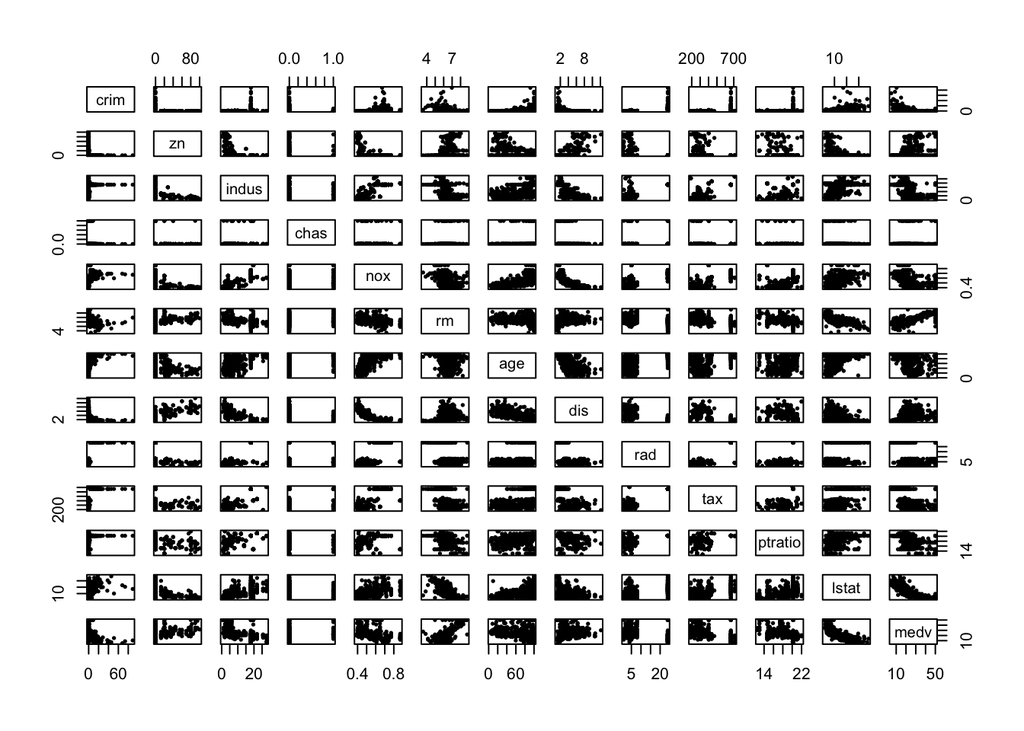

```r
pairs(Boston, pch = 19, cex = 0.35)
```

- Several predictors show clear non-random patterns (association), not just clouds.
- nox tends to increase with indus and with older housing (age), suggesting more industrial/older areas have higher pollution.
- rm (rooms) is positively related to medv (home value).
- lstat (lower status) is strongly negatively related to medv.
- Some predictors are highly skewed (notably crim, zn), and some relationships look non-linear.

### 4.3 (c) Are any predictors associated with per-capita crime rate (crim)? Explain.

```r
crim_cor <- sort(cor(Boston)[, "crim"], decreasing = TRUE)
head(crim_cor, 6)
```

```
     crim       rad       tax     lstat       nox     indus
1.0000000 0.6255051 0.5827643 0.4556215 0.4209717 0.4065834
```

```r
tail(crim_cor, 6)
```

```
    ptratio        chas          zn          rm         dis        medv
 0.28994558 -0.05589158 -0.20046922 -0.21924670 -0.37967009 -0.38830461
```

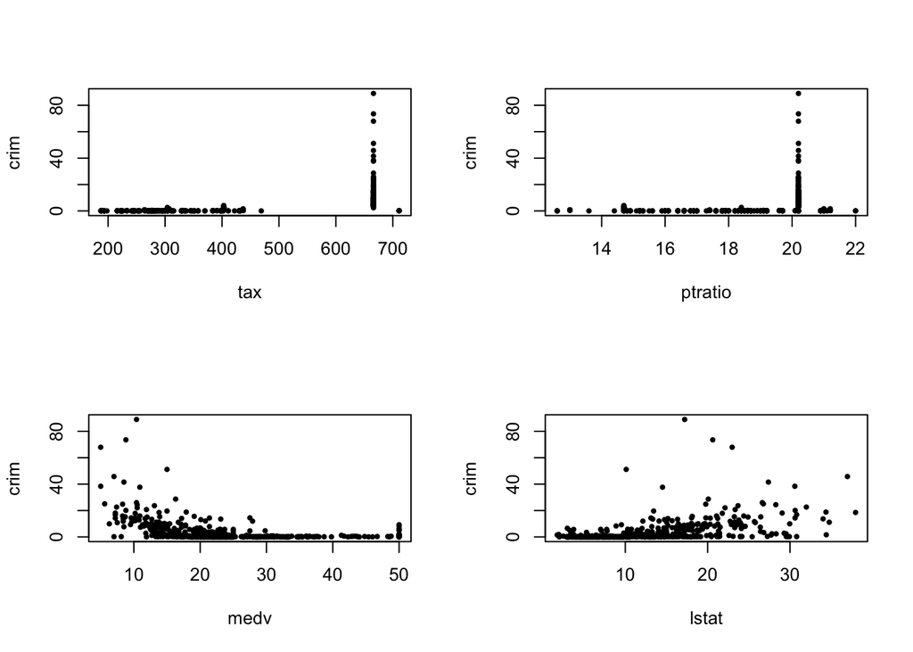

```r
par(mfrow = c(2,2))
plot(Boston$tax, Boston$crim, pch=19, cex=.5, xlab="tax", ylab="crim")
plot(Boston$ptratio, Boston$crim, pch=19, cex=.5, xlab="ptratio", ylab="crim")
plot(Boston$medv, Boston$crim, pch=19, cex=.5, xlab="medv", ylab="crim")
plot(Boston$lstat, Boston$crim, pch=19, cex=.5, xlab="lstat", ylab="crim")
```

```r
par(mfrow = c(1,1))
```

- crim tends to be higher when tax and ptratio are higher (worse-funded/strained areas).
- crim tends to be lower when medv is higher (wealthier areas).
- crim is also higher when lstat is higher (more disadvantage).

### 4.4 (d) Any tracts with particularly high crim, tax, ptratio? Comment on ranges.

```r
rng <- sapply(Boston[, c("crim","tax","ptratio")], range)
rng
```

```
         crim tax ptratio
[1,]  0.00632 187    12.6
[2,] 88.97620 711    22.0
```

```r
top_crim <- order(Boston$crim, decreasing = TRUE)[1:5]
top_tax  <- order(Boston$tax,  decreasing = TRUE)[1:5]
top_ptr  <- order(Boston$ptratio, decreasing = TRUE)[1:5]

Boston[top_crim, c("crim","tax","ptratio","medv","rm","lstat")]
```

```
# A tibble: 5 × 6
   crim   tax ptratio  medv    rm lstat
  <dbl> <dbl>   <dbl> <dbl> <dbl> <dbl>
1  89.0   666    20.2  10.4  6.97  17.2
2  73.5   666    20.2   8.8  5.96  20.6
3  67.9   666    20.2   5    5.68  23.0
4  51.1   666    20.2  15    5.76  10.1
5  45.7   666    20.2   7    4.52  37.0
```

```r
Boston[top_tax,  c("crim","tax","ptratio","medv","rm","lstat")]
```

```
# A tibble: 5 × 6
   crim   tax ptratio  medv    rm lstat
  <dbl> <dbl>   <dbl> <dbl> <dbl> <dbl>
1 0.151   711    20.1  15.2  5.45  18.1
2 0.183   711    20.1   7    5.41  24.0
3 0.207   711    20.1   8.1  5.09  29.7
4 0.106   711    20.1  13.6  5.98  18.1
5 0.111   711    20.1  20.1  5.98  13.4
```

```r
Boston[top_ptr,  c("crim","tax","ptratio","medv","rm","lstat")]
```

```
# A tibble: 5 × 6
    crim   tax ptratio  medv    rm lstat
   <dbl> <dbl>   <dbl> <dbl> <dbl> <dbl>
1 0.0430   334    22    18.2  5.66  8.05
2 0.107    334    22    20.6  5.94  5.57
3 0.259    437    21.2  16.2  5.69 17.2
4 0.325    437    21.2  18    6.43 15.4
5 0.881    437    21.2  14.3  5.64 18.3
```

Yes—there are clearly a few census tracts with extremely high crime rates (strong right-skew). Tax rates and pupil–teacher ratios also have tracts near the upper end, but crim shows the most extreme spread.

### 4.5 (e) How many census tracts bound the Charles River?

```r
sum(Boston$chas == 1)
```

```
[1] 35
```

### 4.6 (f) What is the median pupil–teacher ratio?

```r
median(Boston$ptratio)
```

```
[1] 19.05
```

### 4.7 (g) Which tract has the lowest medv? Compare its predictors to overall ranges.

```r
idx_min_medv <- which.min(Boston$medv)
idx_min_medv
```

```
[1] 399
```

```r
Boston[idx_min_medv, ]
```

```
# A tibble: 1 × 13
   crim    zn indus  chas   nox    rm   age   dis   rad   tax ptratio lstat
  <dbl> <dbl> <dbl> <dbl> <dbl> <dbl> <dbl> <dbl> <dbl> <dbl>   <dbl> <dbl>
1  38.4     0  18.1     0 0.693  5.45   100  1.49    24   666    20.2  30.6
# ℹ 1 more variable: medv <dbl>
```

```r
vars <- names(Boston)
comp <- data.frame(
  variable = vars,
  tract_value = as.numeric(Boston[idx_min_medv, vars]),
  overall_min = sapply(Boston[, vars], min),
  overall_max = sapply(Boston[, vars], max)
)
comp
```

```
        variable tract_value overall_min overall_max
crim        crim     38.3518     0.00632     88.9762
zn            zn      0.0000     0.00000    100.0000
indus      indus     18.1000     0.46000     27.7400
chas        chas      0.0000     0.00000      1.0000
nox          nox      0.6930     0.38500      0.8710
rm            rm      5.4530     3.56100      8.7800
age          age    100.0000     2.90000    100.0000
dis          dis      1.4896     1.12960     12.1265
rad          rad     24.0000     1.00000     24.0000
tax          tax    666.0000   187.00000    711.0000
ptratio  ptratio     20.2000    12.60000     22.0000
lstat      lstat     30.5900     1.73000     37.9700
medv        medv      5.0000     5.00000     50.0000
```

### 4.8 (h) How many tracts have rm > 7? rm > 8? Comment on rm > 8.

```r
n_gt7 <- sum(Boston$rm > 7)
n_gt8 <- sum(Boston$rm > 8)
n_gt7; n_gt8
```

```
[1] 64
```

```
[1] 13
```

```r
Boston[Boston$rm > 8, c("rm","medv","crim","tax","ptratio","lstat","nox")]
```

```
# A tibble: 13 × 7
      rm  medv   crim   tax ptratio lstat   nox
   <dbl> <dbl>  <dbl> <dbl>   <dbl> <dbl> <dbl>
 1  8.07  38.7 0.121    276    18    4.21 0.445
 2  8.38  50   1.52     403    14.7  3.32 0.605
 3  8.03  50   0.0201   224    14.7  2.88 0.416
 4  8.27  44.8 0.315    307    17.4  4.14 0.504
 5  8.72  50   0.527    307    17.4  4.63 0.504
 6  8.04  37.6 0.382    307    17.4  3.13 0.504
 7  8.34  41.7 0.575    307    17.4  2.47 0.507
 8  8.25  48.3 0.331    307    17.4  3.95 0.507
 9  8.26  42.8 0.369    330    19.1  3.54 0.431
10  8.70  50   0.612    264    13    5.12 0.647
11  8.40  48.8 0.520    264    13    5.91 0.647
12  8.30  50   0.578    264    13    7.44 0.575
13  8.78  21.9 3.47     666    20.2  5.29 0.718
```

```r
summary(Boston[Boston$rm > 8, c("rm","medv","crim","tax","ptratio","lstat","nox")])
```

```
       rm             medv           crim              tax
 Min.   :8.034   Min.   :21.9   Min.   :0.02009   Min.   :224.0
 1st Qu.:8.247   1st Qu.:41.7   1st Qu.:0.33147   1st Qu.:264.0
 Median :8.297   Median :48.3   Median :0.52014   Median :307.0
 Mean   :8.349   Mean   :44.2   Mean   :0.71880   Mean   :325.1
 3rd Qu.:8.398   3rd Qu.:50.0   3rd Qu.:0.57834   3rd Qu.:307.0
 Max.   :8.780   Max.   :50.0   Max.   :3.47428   Max.   :666.0
    ptratio          lstat           nox
 Min.   :13.00   Min.   :2.47   Min.   :0.4161
 1st Qu.:14.70   1st Qu.:3.32   1st Qu.:0.5040
 Median :17.40   Median :4.14   Median :0.5070
 Mean   :16.36   Mean   :4.31   Mean   :0.5392
 3rd Qu.:17.40   3rd Qu.:5.12   3rd Qu.:0.6050
 Max.   :20.20   Max.   :7.44   Max.   :0.7180
```

Tracts with rm > 8 generally have high medv, low lstat, and often low crim, consistent with wealthier neighborhoods. They represent an extreme “large houses / high value” subset of the data.

## 5 ISL Exercise 3.7.3 (20% pts)

### 5.1 (a) Which answer is correct, and why?

```r
GPA <- seq(0, 5, by = 0.1)
diff_salary <- 35 - 10 * GPA
GPA[which.min(abs(diff_salary))]
```

- If GPA < 3.5, then college graduates earn more on average.
- If GPA > 3.5, then high school graduates earn more on average.
- If GPA = 3.5, both earn the same on average.

Therefore, the correct answer is **(iii)**:

### 5.2 (b) Predict the salary of a college graduate with IQ = 110 and GPA = 4.0

```r
GPA <- 4.0
IQ <- 110
Level <- 1

salary_hat <- 50 +
  20 * GPA +
  0.07 * IQ +
  35 * Level +
  0.01 * GPA * IQ -
  10 * GPA * Level

salary_hat
```

[output not shown]

### 5.3 (c) True or False: Since the coefficient for the GPA/IQ interaction term is very small, there is very little evidence of an interaction effect.

False.

Although the coefficient for the GPA/IQ interaction term is numerically small (0.01), the interaction term multiplies GPA and IQ, which can be large in practice. Therefore, the interaction effect can still have a meaningful impact on the predicted salary, especially for higher values of GPA and IQ.

## 6 ISL Exercise 3.7.15 (20% pts)

```r
library(ISLR2)
data(Boston)
y <- "crim"
predictors <- setdiff(names(Boston), y)
predictors
```

```
 [1] "zn"      "indus"   "chas"    "nox"     "rm"      "age"     "dis"
 [8] "rad"     "tax"     "ptratio" "lstat"   "medv"
```

### 6.1 (a) Simple linear regression for each predictor

```r
uni_models <- lapply(predictors, function(v) {
  lm(as.formula(paste(y, "~", v)), data = Boston)
})
names(uni_models) <- predictors

uni_summary <- do.call(rbind, lapply(predictors, function(v) {
  sm <- summary(uni_models[[v]])
  data.frame(
    Predictor = v,
    Slope = sm$coefficients[2, 1],
    P_value = sm$coefficients[2, 4],
    R2 = sm$r.squared,
    row.names = NULL
  )
}))

uni_summary <- uni_summary[order(uni_summary$P_value), ]
uni_summary
```

```
   Predictor       Slope      P_value          R2
8        rad  0.61791093 2.693844e-56 0.391256687
9        tax  0.02974225 2.357127e-47 0.339614243
11     lstat  0.54880478 2.654277e-27 0.207590933
4        nox 31.24853120 3.751739e-23 0.177217182
2      indus  0.50977633 1.450349e-21 0.165310070
12      medv -0.36315992 1.173987e-19 0.150780469
7        dis -1.55090168 8.519949e-19 0.144149375
6        age  0.10778623 2.854869e-16 0.124421452
10   ptratio  1.15198279 2.942922e-11 0.084068439
5         rm -2.68405122 6.346703e-07 0.048069117
1         zn -0.07393498 5.506472e-06 0.040187908
3       chas -1.89277655 2.094345e-01 0.003123869
```

```r
uni_sig <- subset(uni_summary, P_value < 0.05)
uni_sig
```

```
   Predictor       Slope      P_value         R2
8        rad  0.61791093 2.693844e-56 0.39125669
9        tax  0.02974225 2.357127e-47 0.33961424
11     lstat  0.54880478 2.654277e-27 0.20759093
4        nox 31.24853120 3.751739e-23 0.17721718
2      indus  0.50977633 1.450349e-21 0.16531007
12      medv -0.36315992 1.173987e-19 0.15078047
7        dis -1.55090168 8.519949e-19 0.14414937
6        age  0.10778623 2.854869e-16 0.12442145
10   ptratio  1.15198279 2.942922e-11 0.08406844
5         rm -2.68405122 6.346703e-07 0.04806912
1         zn -0.07393498 5.506472e-06 0.04018791
```

- Most predictors show a statistically significant association with per capita crime rate at the 5% significance level.
- Predictors such as nox, rad, tax, lstat, ptratio, and indus have extremely small p-values, indicating strong evidence of association.
- A few predictors (for example chas) show weaker or no statistically significant association with crime rate.

```r
top_vars <- head(uni_summary$Predictor, 4)

par(mfrow = c(2,2))
for (v in top_vars) {
  plot(Boston[[v]], Boston$crim,
       xlab = v, ylab = "crim",
       pch = 19, cex = 0.6)
  abline(uni_models[[v]], lwd = 2)
  title(main = paste("crim ~", v))
}
par(mfrow = c(1,1))
```

[output not shown]

### 6.2 (b) Multiple linear regression using all predictors

```r
multi_model <- lm(crim ~ ., data = Boston)
summary(multi_model)
```

```
Call:
lm(formula = crim ~ ., data = Boston)

Residuals:
   Min     1Q Median     3Q    Max
-8.534 -2.248 -0.348  1.087 73.923

Coefficients:
              Estimate Std. Error t value Pr(>|t|)
(Intercept) 13.7783938  7.0818258   1.946 0.052271 .
zn           0.0457100  0.0187903   2.433 0.015344 *
indus       -0.0583501  0.0836351  -0.698 0.485709
chas        -0.8253776  1.1833963  -0.697 0.485841
nox         -9.9575865  5.2898242  -1.882 0.060370 .
rm           0.6289107  0.6070924   1.036 0.300738
age         -0.0008483  0.0179482  -0.047 0.962323
dis         -1.0122467  0.2824676  -3.584 0.000373 ***
rad          0.6124653  0.0875358   6.997 8.59e-12 ***
tax         -0.0037756  0.0051723  -0.730 0.465757
ptratio     -0.3040728  0.1863598  -1.632 0.103393
lstat        0.1388006  0.0757213   1.833 0.067398 .
medv        -0.2200564  0.0598240  -3.678 0.000261 ***
---
Signif. codes:  0 '***' 0.001 '**' 0.01 '*' 0.05 '.' 0.1 ' ' 1

Residual standard error: 6.46 on 493 degrees of freedom
Multiple R-squared:  0.4493,    Adjusted R-squared:  0.4359
F-statistic: 33.52 on 12 and 493 DF,  p-value: < 2.2e-16
```

```r
multi_coef <- summary(multi_model)$coefficients

multi_summary <- data.frame(
  Predictor = rownames(multi_coef),
  Estimate = multi_coef[, 1],
  P_value = multi_coef[, 4],
  row.names = NULL
)

multi_summary_no_intercept <- subset(multi_summary, Predictor != "(Intercept)")
multi_summary_no_intercept[order(multi_summary_no_intercept$P_value), ]
```

```
   Predictor      Estimate      P_value
9        rad  0.6124653115 8.588123e-12
13      medv -0.2200563590 2.605302e-04
8        dis -1.0122467382 3.725942e-04
2         zn  0.0457100386 1.534403e-02
5        nox -9.9575865471 6.036986e-02
12     lstat  0.1388005968 6.739844e-02
11   ptratio -0.3040727572 1.033932e-01
6         rm  0.6289106622 3.007385e-01
10       tax -0.0037756465 4.657565e-01
3      indus -0.0583501107 4.857094e-01
4       chas -0.8253775522 4.858406e-01
7        age -0.0008482791 9.623231e-01
```

```r
multi_sig <- subset(multi_summary_no_intercept, P_value < 0.05)
multi_sig
```

```
   Predictor    Estimate      P_value
2         zn  0.04571004 1.534403e-02
8        dis -1.01224674 3.725942e-04
9        rad  0.61246531 8.588123e-12
13      medv -0.22005636 2.605302e-04
```

At the 5% significance level, we can reject the null hypothesis H0: βj = 0 for predictors with p-values less than 0.05.

### 6.3 (c) Comparison between simple and multiple regression results

```r
uni_slopes <- setNames(uni_summary$Slope, uni_summary$Predictor)

multi_betas <- coef(multi_model)[-1]

common <- intersect(names(uni_slopes), names(multi_betas))

coef_compare <- data.frame(
  Predictor = common,
  Univariate = uni_slopes[common],
  Multiple = multi_betas[common],
  row.names = NULL
)

coef_compare

plot(coef_compare$Univariate, coef_compare$Multiple,
     xlab = "Univariate coefficient (crim ~ X)",
     ylab = "Multiple regression coefficient (crim ~ all X)",
     pch = 19)

abline(0, 1, lty = 2)  # reference line y = x

text(coef_compare$Univariate, coef_compare$Multiple,
     labels = coef_compare$Predictor,
     pos = 4, cex = 0.7)
```

[output not shown]

### 6.4 (d) Evidence of non-linear association (cubic models)

```r
predictors <- setdiff(names(Boston), "crim")

cubic_models <- lapply(predictors, function(v) {
  lm(as.formula(paste0("crim ~ poly(", v, ", 3, raw = TRUE)")), data = Boston)
})
names(cubic_models) <- predictors

cubic_summary <- do.call(rbind, lapply(predictors, function(v) {
  sm <- summary(cubic_models[[v]])
  coefs <- sm$coefficients

  rn <- rownames(coefs)

  x2_name <- paste0("poly(", v, ", 3, raw = TRUE)2")
  x3_name <- paste0("poly(", v, ", 3, raw = TRUE)3")

  p_x2 <- if (x2_name %in% rn) coefs[x2_name, 4] else NA_real_
  p_x3 <- if (x3_name %in% rn) coefs[x3_name, 4] else NA_real_

  data.frame(
    Predictor = v,
    P_X2 = p_x2,
    P_X3 = p_x3,
    Nonlinear_0.05 = (is.finite(p_x2) && p_x2 < 0.05) || (is.finite(p_x3) && p_x3 < 0.05),
    row.names = NULL
  )
}))

cubic_summary <- cubic_summary[order(!cubic_summary$Nonlinear_0.05, cubic_summary$P_X2, cubic_summary$P_X3), ]
cubic_summary
```

[output not shown]

## 7 Bonus question (Extra credits)

For multiple linear regression, show that $R^2$ is equal to the correlation between the response vector $\mathbf{y} = (y_1, \ldots, y_n)^T$ and the fitted values $\hat{\mathbf{y}} = (\hat y_1, \ldots, \hat y_n)^T$. That is
$$R^2 = 1 - \frac{\text{RSS}}{\text{TSS}} = [\operatorname{Cor}(\mathbf{y}, \hat{\mathbf{y}})]^2.$$

#### 7.0.1 Proof

In multiple linear regression with an intercept,

$$R^2 = 1 - \frac{\mathrm{RSS}}{\mathrm{TSS}}.$$

By least squares orthogonality,

$$\mathrm{TSS} = \mathrm{ESS} + \mathrm{RSS},$$

where

$$\mathrm{ESS} = \sum_{i=1}^n (\hat y_i - \bar y)^2.$$

Hence,

$$R^2 = \frac{\mathrm{ESS}}{\mathrm{TSS}}.$$

The sample correlation between $\mathbf y$ and $\hat{\mathbf y}$ is

$$\mathrm{Cor}(\mathbf y, \hat{\mathbf y})
=
\frac{\sum_{i=1}^n (y_i-\bar y)(\hat y_i-\bar y)}
{\sqrt{\mathrm{TSS}\,\mathrm{ESS}}}.$$

Since the residuals are orthogonal to the fitted values,

$$\sum_{i=1}^n (y_i-\bar y)(\hat y_i-\bar y)
=
\sum_{i=1}^n (\hat y_i-\bar y)^2
=
\mathrm{ESS}.$$

Therefore,

$$\mathrm{Cor}(\mathbf y, \hat{\mathbf y})
=
\sqrt{\frac{\mathrm{ESS}}{\mathrm{TSS}}},$$

and squaring both sides yields

$$R^2 = [\mathrm{Cor}(\mathbf y, \hat{\mathbf y})]^2.$$